# Exercise 3 – Classification I

[Introduction to Machine Learning](https://slds-lmu.github.io/i2ml/)

Show All Solutions

Only R | Only Python | Print

## Exercise 1: Logistic regression – softmax link and decision boundary

**TipThe whole exercise is only for lecture group A!**

**NoteLearning goals**

1. Solve “show equivalence”-type questions
2. Derive the decision boundary of the logistic classifier

Binary logistic regression is a special case of multiclass logistic, or softmax, regression. The softmax function is the multiclass analogue to the logistic function, transforming scores $\boldsymbol{\theta}^\top \mathbf{x}$ to values in the range [0, 1] that sum to one. The softmax function is defined as:

$$\pi_k(\mathbf{x}| \boldsymbol{\theta}) = \frac{\exp(\boldsymbol{\theta}_k^\top \mathbf{x})}{\sum_{j=1}^{g} \exp(\boldsymbol{\theta}_j^\top \mathbf{x})}, k \in \{1,...,g\}$$

1. Show that logistic and softmax regression are equivalent for $g = 2$.

**Solution**

As we would expect, the two formulations are equivalent (up to reparameterization). In order to see this, consider the softmax function components for both classes:

$$\pi_1(\mathbf{x}| \boldsymbol{\theta}) = \frac{\exp(\boldsymbol{\theta}_1^\top \mathbf{x})}{\exp(\boldsymbol{\theta}_1^\top \mathbf{x}) + \exp(\boldsymbol{\theta}_2^\top \mathbf{x})}$$

$$\pi_2(\mathbf{x}| \boldsymbol{\theta}) = \frac{\exp(\boldsymbol{\theta}_2^\top \mathbf{x})}{\exp(\boldsymbol{\theta}_1^\top \mathbf{x}) + \exp(\boldsymbol{\theta}_2^\top \mathbf{x})}$$

Since we know that $\pi_1(\mathbf{x}| \boldsymbol{\theta}) + \pi_2(\mathbf{x}| \boldsymbol{\theta}) = 1$, it is sufficient to compute one of the two scoring functions. Let’s pick $\pi_1(\mathbf{x}| \boldsymbol{\theta})$ and relate it to the logistic function:

$$\pi_1(\mathbf{x}| \boldsymbol{\theta}) = \frac{1}{1 + \exp(\boldsymbol{\theta}_2^\top \mathbf{x}- \boldsymbol{\theta}_1^\top \mathbf{x})} = \frac{1}{1 + \exp(-\boldsymbol{\theta}^\top \mathbf{x})}$$

where $\boldsymbol{\theta}:= \boldsymbol{\theta}_1 - \boldsymbol{\theta}_2$. Thus, we obtain the binary-case logistic function, reflecting that we only need one scoring function (and thus one set of parameters $\boldsymbol{\theta}$ rather than two $\boldsymbol{\theta}_1, \boldsymbol{\theta}_2$).

2. Recall that in the binary case we predict $\hat{y} = 1$ iff $\pi(\mathbf{x})\geq \alpha$ for a threshold $\alpha \in (0, 1)$. Show that the resulting decision boundary is a (linear) hyperplane.

   **Hint**

   Derive the value of $\boldsymbol{\theta}^\top \mathbf{x}$ (depending on $\alpha$) starting from which you predict $\hat{y} = 1$ rather than $\hat{y} = 0$.

**Solution**

We evaluate

$$\begin{align*}
\pi(\mathbf{x})&= \frac{1}{1 + \exp(-\boldsymbol{\theta}^\top \mathbf{x})} = \alpha \\
&\Leftrightarrow\ 1 + \exp(-\boldsymbol{\theta}^\top \mathbf{x}) = \frac{1}{\alpha} \\
&\Leftrightarrow\ \exp(-\boldsymbol{\theta}^\top \mathbf{x}) = \frac{1}{\alpha} - 1 \\
&\Leftrightarrow\ -\boldsymbol{\theta}^\top \mathbf{x}= \log \left(\frac{1}{\alpha} - 1 \right) \\
&\Leftrightarrow\ \boldsymbol{\theta}^\top \mathbf{x}= -\log \left(\frac{1}{\alpha} - 1 \right).
\end{align*}$$

$\boldsymbol{\theta}^\top \mathbf{x}= -\log \left(\frac{1}{\alpha} - 1 \right)$ is the equation of a linear hyperplane, consisting of all points $\mathbf{x}$ whose score $\boldsymbol{\theta}^\top \mathbf{x}$ equals $-\log \left(\frac{1}{\alpha} - 1\right)$. Since $\pi(\mathbf{x})$ is increasing in $\boldsymbol{\theta}^\top \mathbf{x}$, we set $\hat y = 1$ for all points on or above this hyperplane, i.e. with $\boldsymbol{\theta}^\top \mathbf{x}\geq -\log \left(\frac{1}{\alpha} - 1\right)$.

## Exercise 2: Hyperplanes

**NoteLearning goals**

1. Understand that hyperplanes bisect the space with a linear boundary
2. Get a feeling for coefficients in hyperplane equations
3. See how the classification threshold $\alpha$ shifts the logistic decision boundary

Linear classifiers like logistic regression learn a decision boundary that takes the form of a (linear) hyperplane. Hyperplanes are defined by equations $\boldsymbol{\theta}^\top \mathbf{x}= b$ with coefficients $\boldsymbol{\theta}$ and a scalar $b \in \mathbb{R}$.

1. In order to see that such expressions actually describe hyperplanes, consider $\boldsymbol{\theta}^\top \mathbf{x}= \theta_0 + \theta_1 x_1 + \theta_2 x_2 = 0$. Sketch the hyperplanes given by the following coefficients and explain the difference between the parameterizations:
   - $\theta_0 = 0, \theta_1 = \theta_2 = 1$
   - $\theta_0 = 1, \theta_1 = \theta_2 = 1$
   - $\theta_0 = 0, \theta_1 = 1, \theta_2 = 2$

**Solution**

A hyperplane in 2D is just a line. We know that two points are sufficient to describe a line, so all we need to do is pick two points fulfilling the hyperplane equation.

- $\theta_0 = 0, \theta_1 = \theta_2 = 1$ $\rightsquigarrow$ e.g., (0, 0) and (1, -1). Sketch it:

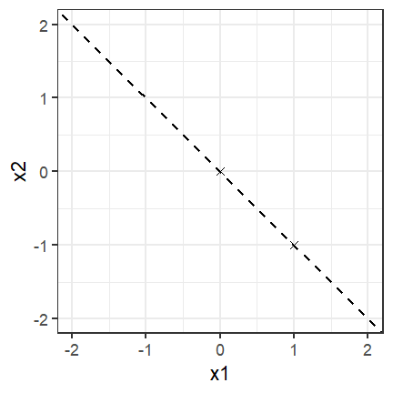

- $\theta_0 = 1, \theta_1 = \theta_2 = 1$ $\rightsquigarrow$ e.g., (0, -1) and (1, -2). The change in $\theta_0$ promotes a horizontal shift:

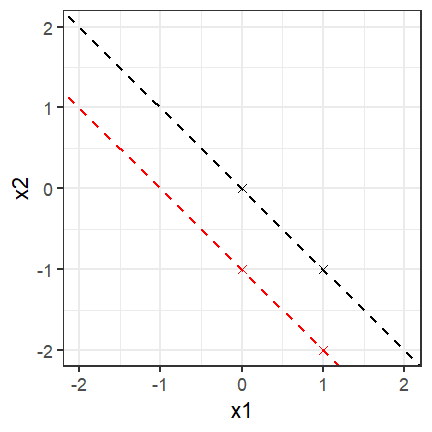

- $\theta_0 = 0, \theta_1 = 1, \theta_2 = 2$ $\rightsquigarrow$ e.g., (0, 0) and (1, -0.5). The change in $\theta_2$ pivots the line around the intercept:

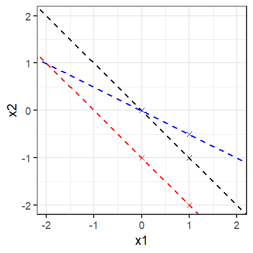

We see that a hyperplane is defined by the points that lie directly on it and thus fulfill the hyperplane equation.

2. Beyond its orientation, a linear classifier also has an *offset* that determines where exactly the boundary sits. Recall that a logistic regression model estimates $\pi(\mathbf{x})= \frac{1}{1 + \exp(-\boldsymbol{\theta}^\top \mathbf{x})}$ and predicts $\hat{y} = 1$ iff $\pi(\mathbf{x})\geq \alpha$ for a threshold $\alpha \in (0, 1)$. Its decision boundary is therefore the hyperplane
   $$\boldsymbol{\theta}^\top \mathbf{x}= -\log\left(\frac{1}{\alpha} - 1\right) =: b(\alpha).$$
   Consider the fixed model $\boldsymbol{\theta}= (\theta_0, \theta_1, \theta_2)^\top = (0, 1, 1)^\top$. Compute the offset $b(\alpha)$ for $\alpha \in \{0.25, 0.5, 0.75\}$, sketch the three resulting decision boundaries in a single $(x_1, x_2)$ plot, and describe how the boundary – and the region predicted as class 1 – changes as $\alpha$ grows. Does the orientation of the boundary change?

**Solution**

For this model, $\boldsymbol{\theta}^\top \mathbf{x}= \theta_0 + \theta_1 x_1 + \theta_2 x_2 = x_1 + x_2$, so every decision boundary is a line $x_1 + x_2 = b(\alpha)$ with slope $-1$ and intercept $b(\alpha)$:

- $\alpha = 0.25$: $b(\alpha) = -\log\left(\frac{1}{0.25} - 1\right) = -\log 3 \approx -1.10$
- $\alpha = 0.5$: $b(\alpha) = -\log\left(\frac{1}{0.5} - 1\right) = -\log 1 = 0$
- $\alpha = 0.75$: $b(\alpha) = -\log\left(\frac{1}{0.75} - 1\right) = -\log \tfrac{1}{3} = \log 3 \approx 1.10$

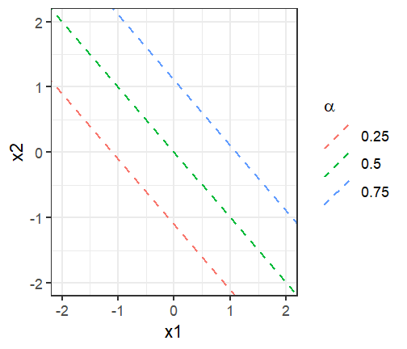

As $\alpha$ increases, the offset $b(\alpha)$ increases and the boundary shifts *parallel* toward the upper right (larger $\boldsymbol{\theta}^\top \mathbf{x}$). Since we predict $\hat{y} = 1$ wherever $\boldsymbol{\theta}^\top \mathbf{x}\geq b(\alpha)$, the region classified as class 1 (the upper-right halfplane) shrinks: a higher threshold makes the model more conservative about predicting class 1. The orientation does **not** change – the normal vector $\boldsymbol{\theta}= (1, 1)^\top$ stays fixed, so all three boundaries are parallel. This mirrors part a), where changing the intercept $\theta_0$ produced a parallel shift of the hyperplane.

Crucially, the fitted model itself – the logistic (S-)curve $\pi(\mathbf{x})= \frac{1}{1 + \exp(-\boldsymbol{\theta}^\top \mathbf{x})}$ – does **not** change when we vary $\alpha$; it depends on $\boldsymbol{\theta}$ alone. Varying $\alpha$ only moves the *horizontal* cut-off through this fixed curve:

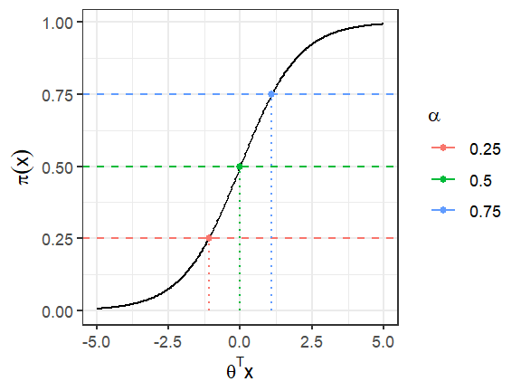

We read off the score $b(\alpha)$ at which the curve reaches height $\pi(\mathbf{x})= \alpha$ (dashed lines) and classify every point with $\boldsymbol{\theta}^\top \mathbf{x}\geq b(\alpha)$ as class 1. Thus $\alpha$ is a *post-hoc decision threshold* applied to fixed predicted probabilities, not a re-fitting of the model. The three cut-off scores $b(\alpha) \in \{-1.10, 0, 1.10\}$ (dotted verticals) are exactly the intercepts of the three parallel decision boundaries in the $(x_1, x_2)$ plot above.

## Exercise 3: Decision Boundaries & Thresholds in Logistic Regression

**NoteLearning goals**

1. Understand that logistic regression finds a linear decision boundary
2. Get a feeling for how the parameters $\boldsymbol{\theta}$ shape predicted probabilities and model confidence
3. Understand the role of the decision threshold $\alpha$

Recall from Exercise 2 that a logistic regression model estimates the probability $p(y = 1 | \mathbf{x}, \boldsymbol{\theta}) = \pi(\mathbf{x}| \boldsymbol{\theta})$ and assigns $\hat{y} = 1$ iff $\pi(\mathbf{x}| \boldsymbol{\theta}) \geq \alpha$ for a threshold $\alpha \in (0, 1)$. Whereas Exercise 2 b) varied the threshold for a fixed model, we now study how the parameters $\boldsymbol{\theta}$ themselves shape the predicted probabilities.

1. Below you see the logistic function for a binary classification problem with two input features for different values $\boldsymbol{\theta}^\top = (\theta_1, \theta_2)^\top$ (plots 1-3) as well as $\alpha$ (plot 4). What can you deduce for the values of $\theta_1$, $\theta_2$, and $\alpha$? What are the implications for classification in the different scenarios? In particular, which of the plots (1)–(3) shows the most confident model?

[interactive chart not shown]

**Solution**

We observe

- in plot (1): the logistic function runs parallel to the $x_2$ axis, so it is the same for every value of $x_2$. In other words, $x_2$ does not contribute anything to the class discrimination and its associated parameter $\theta_2$ is equal to 0.
- in plot (2): both dimensions affect the logistic function – to equal degree in this case, meaning $x_1$ and $x_2$ are equally important. If $\theta_1$ were larger than $\theta_2$ or vice versa the hypersurface would be more tilted towards the respective axis. Furthermore, due to $\theta_1$ and $\theta_2$ being positive, $\pi(\mathbf{x})$ increases with higher values for $x_1$ and $x_2$.
- in plot (3): this is the same situation as in plot (2) but the logistic function is steeper, which is due to $\theta_1, \theta_2$ having larger absolute values. We therefore get a sharper separation between classes (fewer predicted probability values close to 0.5, so we are overall more confident in our decision). As in plot (2), the increasing probability of $\hat{y}=1$ for higher values of $x_1$ and $x_2$ indicates positive values for $\theta_1$ and $\theta_2$.
- in plot (4): this is the same situation as in plot (1). The different values for $\alpha$ represent different thresholds: a high value (leftmost line) means we only assign class 1 if the estimated class-1 probability is large. Conversely, a low value (rightmost line) signifies we are ready to predict class 1 at a low threshold – in effect, this is the same as the previous scenario, only the class labels are flipped. The mid line corresponds to the common case $\alpha = 0.5$ where we assign class 1 as soon as the predicted probability is more than 50%.

In summary, **plot (3)** shows the most confident model: its steeper logistic surface pushes predicted probabilities closer to 0 or 1, yielding the sharpest class separation.

2. In Exercise 2 b) we simply read off the offset $b(0.5) = 0$ for the common threshold $\alpha = 0.5$. Derive this special case directly, starting from $\pi(\mathbf{x})= 0.5$.

**Solution**

At the decision boundary the model is exactly indifferent between the two classes, i.e., $\pi(\mathbf{x})= \alpha = 0.5$:

$$\begin{align*}
\pi(\mathbf{x})= \frac{1}{1 + \exp(-\boldsymbol{\theta}^\top \mathbf{x})} = 0.5
&\Leftrightarrow 1 + \exp(-\boldsymbol{\theta}^\top \mathbf{x}) = 2 \\
&\Leftrightarrow \exp(-\boldsymbol{\theta}^\top \mathbf{x}) = 1 \\
&\Leftrightarrow \boldsymbol{\theta}^\top \mathbf{x}= 0.
\end{align*}$$

The $0.5$ threshold therefore leads to the coordinate hyperplane $\boldsymbol{\theta}^\top \mathbf{x}= 0$ and divides the input space into the positive “1” halfspace where $\boldsymbol{\theta}^\top \mathbf{x}\geq 0$ and the “0” halfspace where $\boldsymbol{\theta}^\top \mathbf{x}< 0$.

3. Explain when it might be sensible to set $\alpha$ to 0.5.

**Solution**

When the threshold $\alpha = 0.5$ is chosen, the losses of misclassified observations, i.e., $L(\hat{y} = 0 ~|~ y = 1)$ and $L(\hat{y} = 1 ~|~ y = 0)$, are treated equally, which is often the intuitive thing to do. It means $\alpha = 0.5$ is a sensible threshold if we do not wish to avoid one type of misclassification more than the other. If, however, we need to be cautious to only predict class 1 if we are very confident (for example, when the decision triggers a costly therapy), it would make sense to set the threshold considerably higher.

## Exercise 4: Thresholds and predictions in practice

**TipThe whole exercise is only for lecture group B!**

**NoteLearning goals**

1. Compute predictions of a logistic model by hand
2. Understand how the threshold $\alpha$ trades off the two error types

Consider a fitted binary logistic regression model with parameter vector $\boldsymbol{\theta}= (\theta_0, \theta_1, \theta_2)^\top = (-1, 2, 1)^\top$, so that
$$\pi(\mathbf{x})= \frac{1}{1 + \exp\left(-(\theta_0 + \theta_1 x_1 + \theta_2 x_2)\right)}.$$
Recall that we predict $\hat{y} = 1$ iff $\pi(\mathbf{x})\geq \alpha$.

1. Compute the predicted probability $\pi(\mathbf{x})$ for the following observations and classify them using the default threshold $\alpha = 0.5$:
   - $\mathbf{x}^{(1)} = (x_1, x_2)^\top = (1, 1)^\top$
   - $\mathbf{x}^{(2)} = (1, -1)^\top$
   - $\mathbf{x}^{(3)} = (0, 0)^\top$

**Solution**

We plug each observation into $\boldsymbol{\theta}^\top \mathbf{x}= \theta_0 + \theta_1 x_1 + \theta_2 x_2$ and apply the logistic function:

- $\mathbf{x}^{(1)}$: $\boldsymbol{\theta}^\top \mathbf{x}= -1 + 2 \cdot 1 + 1 \cdot 1 = 2 \;\Rightarrow\; \pi(\mathbf{x})= \frac{1}{1 + \exp(-2)} \approx 0.88 \;\Rightarrow\; \hat{y} = 1$
- $\mathbf{x}^{(2)}$: $\boldsymbol{\theta}^\top \mathbf{x}= -1 + 2 \cdot 1 + 1 \cdot (-1) = 0 \;\Rightarrow\; \pi(\mathbf{x})= \frac{1}{1 + \exp(0)} = 0.5 \;\Rightarrow\; \hat{y} = 1$ (exactly on the boundary, where $\pi(\mathbf{x})= \alpha$)
- $\mathbf{x}^{(3)}$: $\boldsymbol{\theta}^\top \mathbf{x}= -1 + 2 \cdot 0 + 1 \cdot 0 = -1 \;\Rightarrow\; \pi(\mathbf{x})= \frac{1}{1 + \exp(1)} \approx 0.27 \;\Rightarrow\; \hat{y} = 0$

Note that $\mathbf{x}^{(2)}$ lies exactly on the $\alpha = 0.5$ decision boundary $\boldsymbol{\theta}^\top \mathbf{x}= 0$ derived in Exercise 3 b).

2. For observation $\mathbf{x}^{(1)}$, from which threshold $\alpha$ onwards would the model predict $\hat{y} = 0$ instead?

**Solution**

Since $\hat{y} = 1$ iff $\pi(\mathbf{x})\geq \alpha$, the prediction for $\mathbf{x}^{(1)}$ switches to $\hat{y} = 0$ as soon as $\alpha > \pi(\mathbf{x}^{(1)}) \approx 0.88$. In other words, we would only predict class 0 for this observation if we demanded a class-1 probability of more than about $88\%$.

3. The model is used in a hospital to decide whether to start an expensive and invasive therapy ($\hat{y} = 1$). Would you rather choose a high or a low threshold $\alpha$? Which type of error (false positive / false negative) does your choice avoid, and at what cost?

**Solution**

If the therapy itself is costly and invasive, we want to be sure a patient really needs it before starting it, i.e., only predict $\hat{y} = 1$ when we are very confident. This calls for a **high** threshold $\alpha$: it reduces **false positives** (healthy patients undergoing an unnecessary, harmful therapy), at the price of more **false negatives** (patients who would benefit are not treated).

The “right” choice therefore depends on the relative costs of the two error types. If missing a case were far more dangerous than an unnecessary treatment (e.g., a life-threatening but easily treatable disease), we would instead prefer a **low** $\alpha$ to avoid false negatives.